# SVD Word Embedding for Analogy Tasks

Diego Urdapilleta de la Parra

2024-02-18

## Introduction

In natural language processing (NLP), a word embedding is a mapping between words and vector representations. Each numeric vector assigned to a word is meant to capture certain semantic properties of its word, and the vector space in which these vectors live has different semantic regions as a result. In this mini-project, I will build a word embedding using Singular Value Decomposition (SVD) that is capable of solving analogy tasks. To this end, we start with a co-ocurrence matrix of the 10,000 most frequent words in the English Wikipedia Corpus. For every possible pair of words in the sample, the co-ocurrance matrix contains the number of times the two words appear within a 5-word range of each other. This is a good measure of how related words are to each other, and we will hopefully leverage these co-ocurrances to learn semantic properties of the vocabulary.

The co-ocurrences may be biased by the frequency of the words. That is, a word with a higher absolute frequency will potentially have higher co-ocurrences with other words. For this reason, we start by importing and normalizing the data.

```r
library(tidyverse)
cooccur <- read.csv("data/co_occur.csv", header = FALSE)
dictionary <- read.csv("data/dictionary.txt", header = FALSE)$V1

M_scaled <- apply(cooccur, 1:2, \(x) log(1 + x, base = exp(1)))
```

```r
M_scaled[1:8, 1:8]
```

```
##            V1       V2       V3       V4       V5        V6        V7       V8
## [1,]  0.00000 17.01976 16.42049 15.74289 15.80995 14.765159 14.736948 15.14843
## [2,] 17.01976  0.00000 14.14402 14.65098 13.11286 13.243006 13.417405 12.87662
## [3,] 16.42049 14.14402  0.00000 14.83110 13.90672 14.192440 13.488645 13.03281
## [4,] 15.74289 14.65098 14.83110  0.00000 14.05626 13.955795 13.622667 13.34015
## [5,] 15.80995 13.11286 13.90672 14.05626  0.00000 13.701727 13.406912 12.58246
## [6,] 14.76516 13.24301 14.19244 13.95579 13.70173  0.000000  9.131189 12.49430
## [7,] 14.73695 13.41740 13.48865 13.62267 13.40691  9.131189  0.000000 12.18055
## [8,] 15.14843 12.87662 13.03281 13.34015 12.58246 12.494296 12.180555  0.00000
```

Singular Value Decomposition (SVD) is useful to decompose the normalized co-ocurrence matrix into three separate matrices. Let us denote the normalize co-ocurrence matrix by $M$ and its SVD by $M=U\Sigma V^{\top}$. Then, a few important things are satisfied: 1. Since $M$ is symmetric by construction, the left and right singular vectors (columns of $U$ and $V$, respectively) are the same. 2. By virtue of the decomposition $U\Sigma V^{\top}$, each singular vector $v_i$ has 10,000 coordinates with can be interpreted to correspond to the 10,000 words. Thus, each singular vector captures certain semantic information, with higher-valued coordinates corresponding to semantically relevant words. 3. Finally, SVD allows us to potentially construct a low-rank approximation $U_{[100]}\Sigma_{[100]}V^{\top}_{[100]}$ of our matrix $M$, which will make computations easier.

We begin by obtaining the SVD of $M$ and constructing its 100-rank approximation.

```r
# SVD:
svd_M <- svd(M_scaled, nu = 100, nv = 100)

s_values <- svd_M$d
right_s_vectors <- svd_M$u
rownames(right_s_vectors) <- dictionary
left_s_vectors <- svd_M$v
rownames(left_s_vectors) <- dictionary

# Compute the approximation:
M_approx <- right_s_vectors %*% diag(s_values) %*% t(left_s_vectors)
```

```r
M_approx[1:8, 1:8]
```

```
##          the       of       in      and       to       was        is      for
## the 18.74121 18.02966 16.85459 16.52658 15.39284 15.364185 15.747122 15.35385
## of  18.03039 18.44119 15.44461 15.90409 14.31136 13.020894 13.849159 14.10753
## in  16.85589 15.44462 16.25455 15.58602 13.99404 14.216726 14.105687 13.75160
## and 16.52769 15.90349 15.58493 16.41971 14.85753 14.506990 14.498245 13.94978
## to  15.39366 14.30999 13.99151 14.85604 17.86054 12.493251 12.437435 13.24067
## was 15.36542 13.02097 14.21681 14.50808 12.49563 10.411075  8.698442 12.39715
## is  15.74822 13.85005 14.10726 14.50048 12.44047  8.699843 10.716997 12.29884
## for 15.35543 14.10738 13.75127 13.95081 13.24350 12.396766 12.296700 14.19431
```

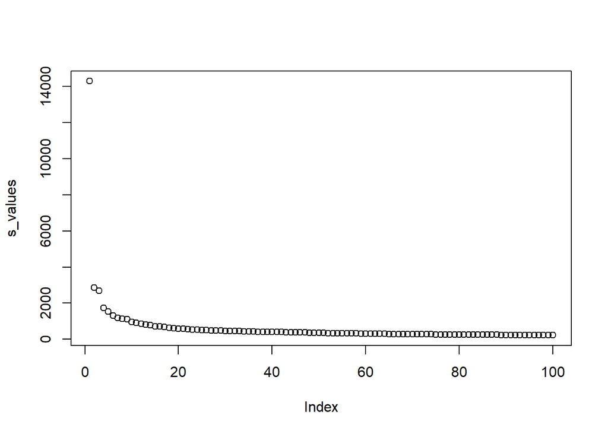

```r
plot(s_values)
```

```r
s_values[1:20]
```

```
##  [1] 14299.7431  2864.8156  2682.6538  1745.5549  1528.4172  1308.7619
##  [7]  1185.7405  1128.0526  1102.5571   956.3077   916.0537   853.3530
## [13]   820.3448   773.6605   719.6944   701.5217   678.1840   642.6452
## [19]   617.5387   594.8363
```

As can be seen in the plot, the first few singular values are much larger than the rest. This tells us that $M$ is well approximated by a low-rank matrix. In particular, we will use a rank 100 approximation which results in a 100-dimensional vector space were our word embeddings live. In what follows, we will explore this 100-dimensional word space and see if we can find semantic regions and semantic information captured by the singular vectors.

## Examining Some Examples

We take the absolute value of the singular vectors, extract the top 10 highest entry values, and map them to their associated word.

```r
# Create empty matrices to store the top words of each vector.
pos_top_words <- matrix(rep(0, 10*100), nrow = 10)
neg_top_words <- matrix(rep(0, 10*100), nrow = 10)
colnames(pos_top_words) <- paste("v", 1:100, sep = "")
colnames(neg_top_words) <- paste("v", 1:100, sep = "")

# Fill the matrix with a loop.
for(i in 1:100){
  # We sort each vector and extract the first 10 row names.
  pos_top_words[,i] <- names(sort(right_s_vectors[, i], decreasing = TRUE))[1:10]
  neg_top_words[,i] <- names(sort(right_s_vectors[, i], decreasing = FALSE))[1:10]
}

pos_top_words[, 1:6]
```

```
##       v1             v2     v3        v4           v5           v6
##  [1,] "gmina"        "the"  "born"    "district"   "political"  "digital"
##  [2,] "insee"        "and"  "john"    "county"     "social"     "science"
##  [3,] "householder"  "of"   "james"   "council"    "religious"  "software"
##  [4,] "increment"    "in"   "david"   "university" "law"        "technology"
##  [5,] "peakposition" "to"   "robert"  "national"   "legal"      "engineering"
##  [6,] "midst"        "for"  "william" "regional"   "policy"     "computer"
##  [7,] "outskirts"    "with" "jr"      "government" "rights"     "research"
##  [8,] "iucn"         "as"   "george"  "department" "government" "online"
##  [9,] "voivodeship"  "by"   "thomas"  "northern"   "minister"   "web"
## [10,] "subtropical"  "is"   "michael" "municipal"  "jewish"     "electronic"
```

```r
neg_top_words[, 1:6]
```

```
##       v1     v2             v3          v4        v5         v6
##  [1,] "the"  "innings"      "specific"  "you"     "jpg"      "troops"
##  [2,] "and"  "tournaments"  "any"       "album"   "km"       "him"
##  [3,] "of"   "leagues"      "data"      "love"    "located"  "killed"
##  [4,] "in"   "constituency" "provide"   "me"      "near"     "soldiers"
##  [5,] "to"   "medals"       "these"     "my"      "road"     "they"
##  [6,] "for"  "locomotives"  "certain"   "song"    "river"    "them"
##  [7,] "as"   "households"   "different" "episode" "lake"     "were"
##  [8,] "is"   "manga"        "systems"   "your"    "route"    "had"
##  [9,] "with" "billboard"    "its"       "vocals"  "station"  "emperor"
## [10,] "was"  "theaters"     "use"       "baby"    "mountain" "attacked"
```

This way, we can get an idea about the general semantic region that each vector is pointing at. I will not include the output for the whole 100 singular vectors here. However, in the small sample above we can already identify interesting sets of words relating to, for example, names in vector 3, politics in vector 5, and technology or warfare in vector 6.

We will examine, as examples, singular vectors 10, 35, 48, 60, and 97. We can again retrieve the top ten positive and top ten negative values using the same matrices as above:

```r
example_vectors <- c(10, 35, 48, 60, 97)
pos_top_words[, example_vectors]
```

```
##       v10            v35         v48          v60        v97
##  [1,] "community"    "norwegian" "drama"      "colonial" "five"
##  [2,] "downtown"     "austrian"  "television" "complex"  "several"
##  [3,] "students"     "canadian"  "tv"         "memory"   "six"
##  [4,] "campus"       "belgian"   "actress"    "tennis"   "four"
##  [5,] "schools"      "swedish"   "comedy"     "governor" "were"
##  [6,] "public"       "chamber"   "starring"   "swimming" "seven"
##  [7,] "residents"    "swiss"     "directed"   "long"     "eight"
##  [8,] "neighborhood" "amateur"   "film"       "cricket"  "three"
##  [9,] "college"      "british"   "actor"      "baseball" "been"
## [10,] "park"         "german"    "nbc"        "sir"      "numerous"
```

```r
neg_top_words[, example_vectors]
```

```
##       v10         v35           v48        v60         v97
##  [1,] "ii"        "ce"          "party"    "saint"     "which"
##  [2,] "commander" "traditional" "car"      "christian" "where"
##  [3,] "german"    "support"     "chart"    "catholic"  "who"
##  [4,] "de"        "style"       "leader"   "primary"   "whom"
##  [5,] "iii"       "improved"    "label"    "critics"   "that"
##  [6,] "squadron"  "wing"        "election" "german"    "gain"
##  [7,] "mm"        "hp"          "business" "main"      "under"
##  [8,] "aircraft"  "islam"       "race"     "holy"      "taking"
##  [9,] "iv"        "text"        "group"    "orthodox"  "here"
## [10,] "command"   "ad"          "key"      "rating"    "receiving"
```

There appears to be a sharp distinction between the semantic regions of the top positive words and the top negative words for each vector, with one of the two being generally more definite than the other. In vector 60, for instance, it is easy to see that the words corresponding to the top negative values are very strongly related to each other, while the relationship seems to be weaker among those of the largest positive values. For vector 10, however, both the top positive values and the top negative values are semantically cohesive, but mutually quite different.

## Finding the Location of Words in the Space

In this section, we will examine the “location” of some interesting words in our embedding space. Specifically, we will look at the words “boy”, “girl”, “brother”, “sister”, “king”, “queen”, “he”, “she”, “John”, “Mary”, “wall”, and “tree” in the hopes of identifying directions and regions related to gender.

```r
# Normalize the rows of the singular vector matrix
vectors <- t(apply(right_s_vectors, 1, function(x){x / norm(x, "2")}))
rownames(vectors) <- dictionary
```

(Note: while assigning `vectors` (which represents the matrix $V$), we had to take the transpose with `t()` because, although our inputs were matrix rows, the `apply` function always outputs matrix columns. )

```r
V_1 <- vectors["woman",]
V_2 <- vectors["man",]
V <- V_1 - V_2
```

Since each row vector $v$ of ${V}$ is a unit vector, the scalar projection of $u$ over $v$ for any $u\in\R^{100}$ is simply given by the dot product $u^{\top}v$. Let $U_{\text{boy}}, U_{\text{girl}}, U_{\text{brother}}, \ldots\in\R^{100}$ be the word embeddings for the indexed words. We can get the projections $U_i^{\top}V$ through the following matrix product:
$$\begin{bmatrix}
- & U_{\text{boy}}^{\top} & - \\[2mm]
- & U_{\text{girl}}^{\top} & - \\[2mm]
- & U_{\text{brother}}^{\top} & - \\[2mm]
& \vdots &\\[2mm]
- & U_{\text{tree}}^{\top} & - \\[2mm]
\end{bmatrix} V = \begin{bmatrix}
- & U_{\text{boy}}^{\top}V & - \\[2mm]
- & U_{\text{girl}}^{\top}V & - \\[2mm]
- & U_{\text{brother}}^{\top}V & - \\[2mm]
& \vdots &\\[2mm]
- & U_{\text{tree}}^{\top}V & - \\[2mm]
\end{bmatrix}.$$

Note that the matrix used in the left-hand side is simply a submatrix of ${V}$. We take advantage of this in the following code lines.

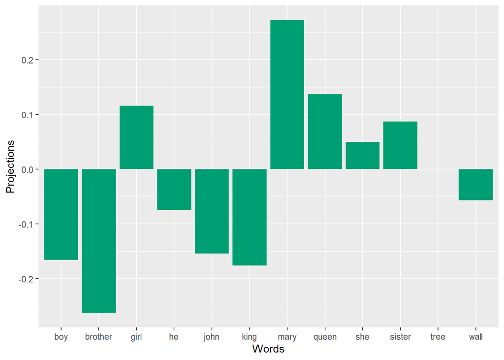

```r
words <- c("boy", "girl", "brother", "sister", "king", "queen", "he", "she",
           "john", "mary", "wall", "tree")
indices <- which(dictionary %in% words)

# This step is necessary to ensure that both indices and words are in the same
# corresponding order
words <- rownames(vectors[indices, ])

projections_V <- vectors[indices, ] %*% V

proj_tibble <- tibble(words, projections_V)

proj_tibble %>%
  ggplot(aes(x = words, y = projections_V)) +
  geom_col(fill = "#009E73") +
  labs(y = "Projections", x = "Words")
```

Now consider the words “math”, “matrix”, “history”, “nurse”, “doctor”, “pilot”, “teacher”, “engineer”, “science”, “arts”, “literature”, “Bob”, and “Alice.” Using the same procedure as above, we have:

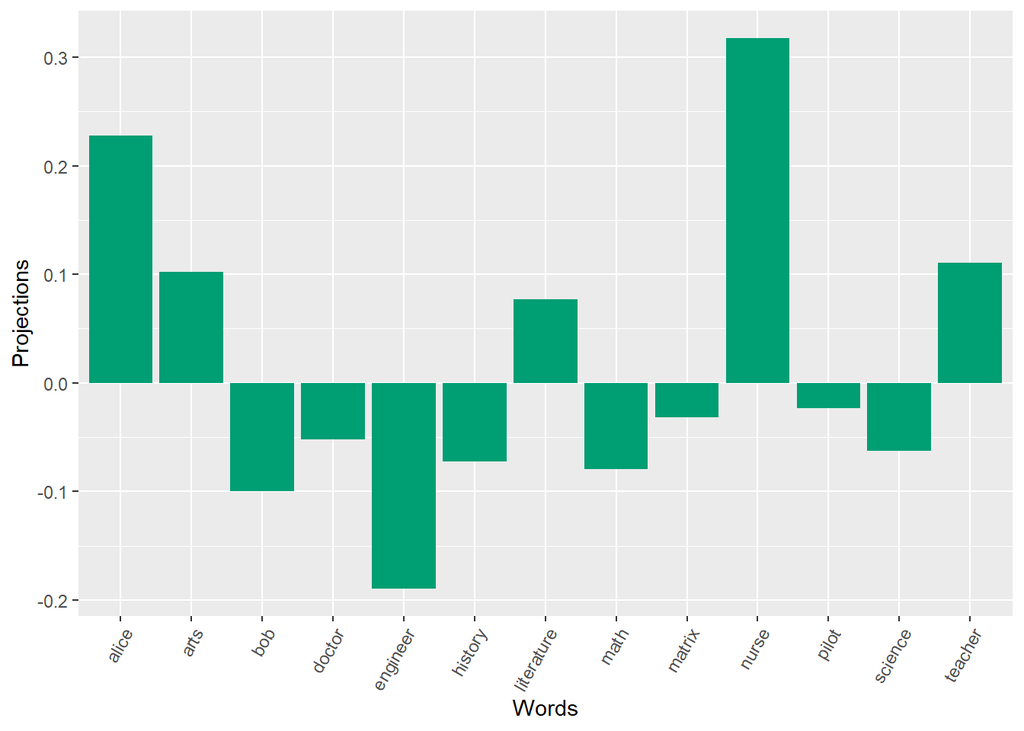

```r
words <- c("math", "matrix", "history", "nurse", "doctor", "pilot", "teacher",
           "engineer", "science", "arts", "literature", "bob", "alice")
indices <- which(dictionary %in% words)

# This step is necessary to ensure that both indices and words are in the same
# corresponding order.
words <- rownames(vectors[indices, ])

projections_V <- vectors[indices, ] %*% V

proj_tibble <- tibble(words, projections_V)

proj_tibble %>%
  ggplot(aes(x = words, y = projections_V)) +
  geom_col(fill = "#009E73") +
  labs(y = "Projections", x = "Words") +
  theme(axis.text.x = element_text(angle = 60, vjust = 1, hjust=1))
```

These results reflect underlying occupational and educational gender biases that exist within the English Wikipedia Corpus. In the real world, we may be able to identify the political and social factors that bring upon these biases and attempt to mitigate them. This word-embeddings model, however, cannot make such a judgement and will simply associate certain occupations with one gender or the other. This is problematic because, in practice, decisions made using the model will carry and perpetuate undesirable gender roles.

### Finding similarity between words

A key step in identifying semantic regions is finding a way to measure “distance” between words. For word embeddings $v_{i}$ and $v_{j}$, we define their cosine similarity to be

$$d(v_{i}, v_{j}) =
\frac{v_{i}^{\top}v_{j}}{||v_{i}||\,||v_{j}||},$$
where $||\cdot||$ denotes the $l_{2}$ norm. Since our vectors are standardized, $||v_{i}|| = 1$ for all $i\in [10,000]$, so that $d(v_{i}, v_{j}) = {v_{i}^{\top}v_{j}}$. Below, we illustrate this distance measure by finding the words closest to “Montreal”:

```r
d_montreal <- function(word){
  vectors[word, ] %*% vectors["montreal", ]
}

similar_montreal <- sapply(dictionary, d_montreal) %>%
  sort(decreasing = TRUE) %>%
  names()

similar_montreal[1:30]
```

```
##  [1] "montreal"     "vancouver"    "toronto"      "ottawa"       "winnipeg"
##  [6] "calgary"      "edmonton"     "detroit"      "quebec"       "atlanta"
## [11] "seattle"      "melbourne"    "philadelphia" "portland"     "ontario"
## [16] "pittsburgh"   "manitoba"     "buffalo"      "regina"       "boston"
## [21] "chicago"      "perth"        "angeles"      "tampa"        "sydney"
## [26] "brisbane"     "brussels"     "alberta"      "minneapolis"  "saskatchewan"
```

We see that the top 30 closest word embeddings to “Montreal” represent city and province names, with Canadian cities being prevalent.

## Solving Analogy Tasks

Analogy tasks are questions of the form “man is to woman as king is to what?”. Using a trigonometric approach, we can navigate our embedding space to solve such tasks. Specifically, we would find the word closest to the vector $U_{\text{woman}} - U_{\text{man}} + U_{\text{king}}$. To test our embedding’s performance on this type of tasks, the file `analogy_task.txt` contains close to 5,600 analogy tasks. The code below applies the embedding on this set.

The function below solved the analogy task by computing the expression above. It then removes the words already involved in the analogy from the possible guesses. Finally, it obtains the $n$ closest words to the analogy solution vector.

```r
solve_analogy <- function(row_vector, n_of_guesses = 5){
  v1 <- vectors[row_vector[1], ]
  v2 <- vectors[row_vector[2], ]
  v3 <- vectors[row_vector[3], ]
  target <- v2 - v1 + v3

  # Obtain the indices for the chosen words and remove them from possible guesses
  indices <- which(dictionary %in% c(row_vector[1],
                                     row_vector[2],
                                     row_vector[3])
                   )
  possible_vectors <- vectors[-indices, ]

  # Obtain the nearest word embeddings to the target:
  distances <- apply(possible_vectors, 1, \(x) x %*% target)
  result <- sort(distances, decreasing = TRUE) %>% names()

  result[1:n_of_guesses]
}

# Function for testing solve_analogy on rows of a dataset:
test <- function(data, n = 1){
  guesses <- apply(data, 1, solve_analogy, n_of_guesses = n)

  # For n>1, apply will return a matrix with a column output for each row input.
  # We want to turn these column outputs back to rows, and we use t().
  if(n>1){
    guesses <- t(guesses)
    colnames(guesses) <- paste("guess", 1:n, sep = "_")
  }

  cbind(data, guesses)
}
```

We can now apply these functions to `analogy_task.txt`.

```r
analogy_task <- read.csv("data/analogy_task.txt", header = FALSE, sep = " ")
test(analogy_task[1:8, ], n=3)
```

```
##       V1     V2       V3        V4   guess_1   guess_2   guess_3
## 1 athens greece  bangkok  thailand  thailand indonesia  malaysia
## 2 athens greece  beijing     china     korea  thailand indonesia
## 3 athens greece   berlin   germany   germany   austria    poland
## 4 athens greece    cairo     egypt   morocco   algeria   tunisia
## 5 athens greece canberra australia   iceland  tanzania australia
## 6 athens greece helsinki   finland   iceland   finland   estonia
## 7 athens greece   london   england   ireland   britain   england
## 8 athens greece   madrid     spain argentina  portugal     spain
```

The following line of code stores the output of applying `test` on the complete dataset:

```r
test_results <- test(analogy_task, n = 5)
```

```r
# Filter the results to obtain the rows where all five guesses were wrong:
failed_tasks <- test_results %>%
  filter(!Reduce(`|`, lapply(select(., -V4), \(x) x == V4)))

head(failed_tasks)
```

```
##         V1        V2       V3        V4     guess_1      guess_2    guess_3
## 1   athens    greece    cairo     egypt     morocco      algeria    tunisia
## 2 canberra australia helsinki   finland netherlands      germany     sweden
## 3   london   england   ottawa    canada      quebec saskatchewan   manitoba
## 4   london   england canberra australia       wales   canterbury queensland
## 5   ottawa    canada   london   england   australia           uk    britain
## 6     rome     italy  beijing     china       korea     thailand     taiwan
##       guess_4  guess_5
## 1      arabia   turkey
## 2 switzerland   norway
## 3     ontario      nhl
## 4    scotland tasmania
## 5     ireland   europe
## 6    malaysia    japan
```

```r
dim(failed_tasks)
```

```
## [1] 1412    9
```

```r
dim(analogy_task)
```

```
## [1] 5585    4
```

There were 1,412 analogies for which the model’s top five answers were incorrect. Considering that the total number of analogies provided was 5,585, the model guessed correctly $1 - 1,412/5,585 \approx 75\%$ of the time. Most guesses, however, are at least close in the type of word, conjugation, or general semantic region.

Looking at the table for `failed_tasks`, there does not seem to be a particular type of analogy at which the model struggled most. However, I chose three that I found interesting:

```r
failed_tasks[c(902, 945, 1285),]
```

```
##         V1      V2    V3       V4    guess_1   guess_2  guess_3    guess_4
## 902    bad   worse  good   better reasonable excellent adequate consistent
## 945    big biggest small smallest    largest     large  smaller     larger
## 1285 eagle  eagles   eye     eyes     tigers     bulls panthers      lions
##      guess_5
## 902  perfect
## 945     huge
## 1285 raiders
```

Another recurring mistake I found occurs with analogies that refer to the English nationality:

```r
failed_tasks[c(1021, 1024, 1026, 1029, 1033, 1040, 1044, 1048, 1053), ]
```

```
##               V1         V2      V3      V4  guess_1 guess_2 guess_3 guess_4
## 1021   australia australian england english scottish   irish   welsh british
## 1024     austria   austrian england english scottish   irish   welsh british
## 1026      brazil  brazilian england english scottish   welsh   irish  danish
## 1029       chile    chilean england english scottish   irish   welsh  danish
## 1033       egypt   egyptian england english scottish   irish   welsh  danish
## 1040       india     indian england english scottish   irish   welsh british
## 1044      israel    israeli england english scottish   irish   welsh british
## 1048      mexico    mexican england english scottish   irish   welsh  danish
## 1053 switzerland      swiss england english scottish   irish   welsh british
##         guess_5
## 1021     danish
## 1024 australian
## 1026    british
## 1029    british
## 1033    italian
## 1040     danish
## 1044  yorkshire
## 1048    british
## 1053     danish
```

Interestingly, the model’s guesses were very close to the correct answer (referring to other nationalities in the UK) but failed to hit the right one. I think it is likely that the word embedding for “English” is heavily dominated by the language-related meaning of the word, hence removing it from the 100-dimensional “region” of nationalities.

Since all 10,000 word embeddings are being represented in a 100-dimensional space, there is simply not enough room for all vectors to be “spaced” and sorted in the most optimal way. Mistakes like the above are therefore bound to happen.